## Course: COMPUTATIONAL THINKING FOR GOVERNANCE ANALYTICS

### Prof. José Manuel Magallanes, PhD

- Visiting Professor of Computational Policy at Evans School of Public Policy and Governance, and eScience Institute Senior Data Science Fellow, University of Washington.
- Professor of Government and Political Methodology, Pontificia Universidad Católica del Perú.

# Session 6: Intro to R (III)

Collect the data we prepared in Python:

```r
link='https://github.com/UWDataScience2020/data/raw/master/hdidemocia.RDS'
# a RDS file from the web needs:
myFile=url(link)

# reading in data:
fromPy=readRDS(file = myFile)

# reset indexes to R format:
row.names(fromPy)=NULL
```

Verifying data structure:

```r
str(fromPy,width = 70,strict.width='cut')
```

```
## 'data.frame':    164 obs. of  16 variables:
##  $ Country                     : chr  "Norway" "Switzerland" "Irela"..
##  $ Humandevelopmentindex       : num  0.954 0.946 0.942 0.939 0.939 ..
##  $ Lifeexpectancyatbirth       : num  82.3 83.6 82.1 81.2 84.7 83.3 ..
##  $ Expectedyearsofschooling    : num  18.1 16.2 18.8 17.1 16.5 22.1 ..
##  $ Meanyearsofschooling        : num  12.6 13.4 12.5 14.1 12 12.7 12..
##  $ Grossnationalincomepercapita: num  68059 59375 55660 46946 60221 ..
##  $ Score                       : num  9.87 9.03 9.24 8.68 6.02 9.09 ..
##  $ Electoralprocessandpluralism: num  10 9.58 10 9.58 3.58 10 10 9.5..
##  $ Functioningofgovernment     : num  9.64 9.29 7.86 8.57 4.36 8.93 ..
##  $ Politicalparticipation      : num  10 7.78 8.33 8.33 6.11 7.78 8...
##  $ Politicalculture            : num  10 9.38 10 7.5 7.5 8.75 10 10 ..
##  $ Civilliberties              : num  9.71 9.12 10 9.41 8.53 10 9.71..
##  $ Regimetype                  : Ord.factor w/ 4 levels "Authoritar"..
##  $ Continent                   : Factor w/ 7 levels "Africa","Asia",..
##  $ countries                   : chr  "Norway" "Switzerland" "Irela"..
##  $ co2_in_MT                   : num  3.98e+07 3.90e+07 3.69e+07 8.4..
```

# Unsupervised ML: Dimensionality Reduction

You would like turn the 5 dimensions of democracy index into one, without following an arithmetic approach, but an algebraic one, instead. Dimension reduction is the job of latent variable analysis, and that’s the way proposed here.

Let me first create some fake columns that represent values I do not have:

```r
library(matlab)
top=10*as.vector(ones(1,5))
bottom=as.vector(zeros(1,5))
# those become two rows of a data frame
limitCases=as.data.frame(rbind(bottom,top))
limitCases
```

```
##        V1 V2 V3 V4 V5
## bottom  0  0  0  0  0
## top    10 10 10 10 10
```

I have create a two-row data frame only because the original data do not have those values.

Let me subset our original data frame:

```r
subDemo=fromPy[,c(8:12)]
```

Now, let me append the small one to this last one.

```r
# FIRST, we need both DFs share same column names
names(limitCases)=names(subDemo)
# appending:
subDemo=rbind(subDemo,limitCases)
```

Our *subDemo* DF has the data to compute the one index we need. I will show the technique called **confirmatory factor analysis**:

```r
names(subDemo)
```

```
## [1] "Electoralprocessandpluralism" "Functioningofgovernment"
## [3] "Politicalparticipation"       "Politicalculture"
## [5] "Civilliberties"
```

```r
library(lavaan)
model='
dem=~Electoralprocessandpluralism + Functioningofgovernment + Politicalparticipation + Politicalculture + Civilliberties
'

fit<-cfa(model, data = subDemo,std.lv=TRUE)
indexCFA=lavPredict(fit)
```

The index computed is not in a range from 1 to 10:

```r
library(magrittr)
indexCFA%>%head(10)
```

```
##             dem
##  [1,] 1.6496645
##  [2,] 1.3678323
##  [3,] 1.5404722
##  [4,] 1.3667723
##  [5,] 0.5087909
##  [6,] 1.5408470
##  [7,] 1.5811966
##  [8,] 1.4875217
##  [9,] 0.3263476
## [10,] 1.3764511
```

We force its return to “0 to 10”:

```r
library(scales)
indexCFANorm=rescale(as.vector(indexCFA), to = c(0, 10))
```

The last rows need to be eliminated:

```r
tail(indexCFANorm)
```

```
## [1]  1.973804  1.852225  1.692379  3.776136  0.000000 10.000000
```

So, this is our index:

```r
fromPy$demo_FA=head(indexCFANorm,-2)
```

Let me plot this index:

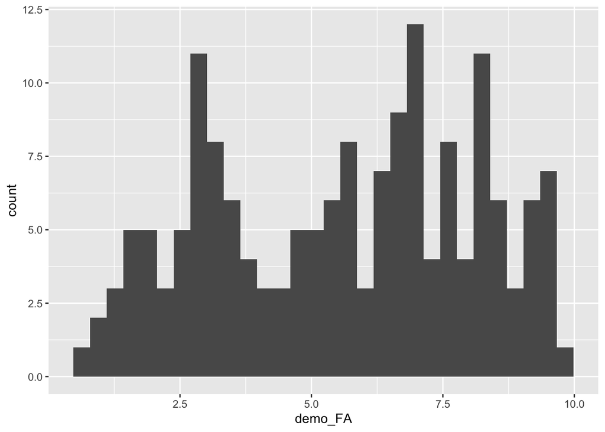

```r
library(ggplot2)
base=ggplot(data=fromPy,
            aes(x=demo_FA))
base+geom_histogram()
```

Let me compare the new index with the original score:

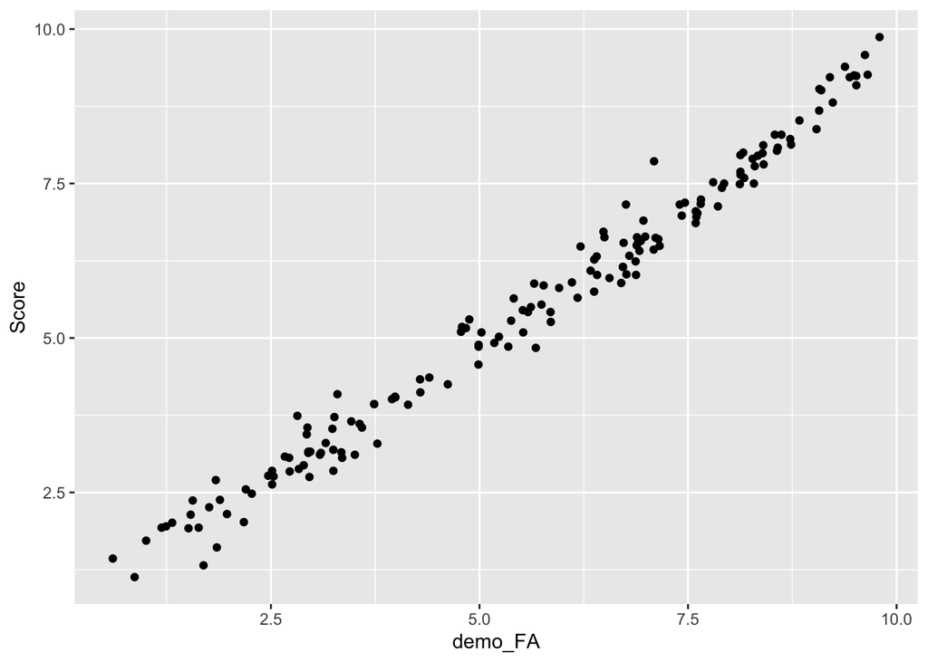

```r
base=ggplot(data=fromPy,
            aes(x=demo_FA,y=Score))
base+geom_point()
```

Let me see some evaluation measures of our index for democracy:

```r
evalCFA1=parameterEstimates(fit, standardized =TRUE)
```

- Loadings

```r
evalCFA1[evalCFA1$op=="=~",c('rhs','std.all','pvalue')]
```

```
##                            rhs std.all pvalue
## 1 Electoralprocessandpluralism   0.926      0
## 2      Functioningofgovernment   0.888      0
## 3       Politicalparticipation   0.829      0
## 4             Politicalculture   0.696      0
## 5               Civilliberties   0.971      0
```

- Some coefficients:

```r
evalCFA2=as.list(fitMeasures(fit))
```

- You want p.value of Chi-Square greater than 0.05:

```r
evalCFA2[c("chisq", "df", "pvalue")]
```

```
## $chisq
## [1] 38.76355
##
## $df
## [1] 5
##
## $pvalue
## [1] 2.649806e-07
```

- You want the Tucker-Lewis > 0.9:

```r
evalCFA2$tli # > 0.90
```

```
## [1] 0.9177665
```

- You want RMSEA < 0.05:

```r
evalCFA2[c( 'rmsea.ci.lower','rmsea','rmsea.ci.upper')]
```

```
## $rmsea.ci.lower
## [1] 0.1454452
##
## $rmsea
## [1] 0.2016903
##
## $rmsea.ci.upper
## [1] 0.2630742
```

You can see how it looks:

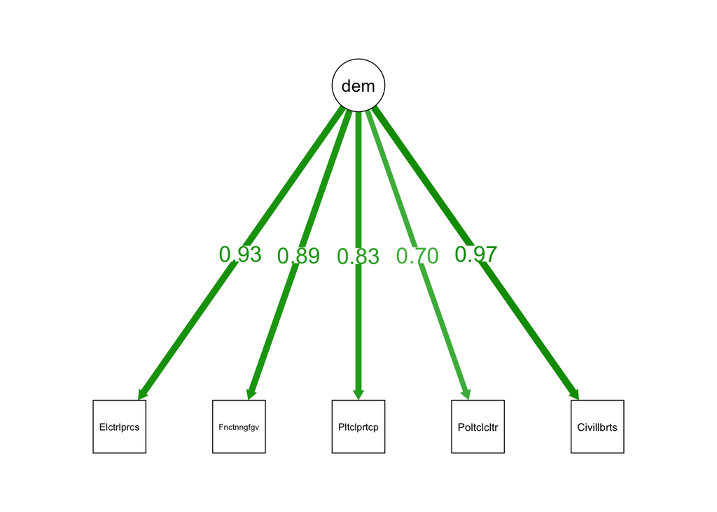

```r
library(semPlot)
semPaths(fit, what='std', nCharNodes=10, sizeMan=8,
         edge.label.cex=1.5, fade=T,residuals = F)
```

# Supervised ML: Regression

## Continuous outcome

### * **EXPLANATORY APPROACH**

1. State hypotheses:

```r
# hypotheses:
hypo1=formula(co2_in_millionMT~ demo_FA + Humandevelopmentindex)
hypo2=formula(co2_in_millionMT~ demo_FA + Humandevelopmentindex + Continent)
```

2. Rescale units if needed into a new variable:

```r
fromPy$co2_in_millionMT=fromPy$co2_in_MT/10^6
```

3. Save columns needed:

```r
colsNeeded=c('co2_in_millionMT', 'demo_FA','Humandevelopmentindex','Continent')
```

4. Verify data types:

Explore variables you will use in **hypothesis**:

```r
str(fromPy[,colsNeeded])
```

```
## 'data.frame':    164 obs. of  4 variables:
##  $ co2_in_millionMT     : num  39.8 39 36.9 847.6 102.5 ...
##  $ demo_FA              : num  9.8 9.07 9.52 9.07 6.88 ...
##  $ Humandevelopmentindex: num  0.954 0.946 0.942 0.939 0.939 0.938 0.938 0.937 0.935 0.933 ...
##  $ Continent            : Factor w/ 7 levels "Africa","Asia",..: 3 3 3 3 2 6 3 3 2 3 ...
```

5. Create subset:

```r
DataRegGauss=fromPy[,colsNeeded]
#Rename indexes by country
row.names(DataRegGauss)=fromPy$Country
```

6. Compute regression models:

```r
#
# results
gauss1=glm(hypo1,data = DataRegGauss,family = 'gaussian')
gauss2=glm(hypo2,data = DataRegGauss,family = 'gaussian')
```

7. See results:
- First Hypothesis

```r
summary(gauss1)
```

```
##
## Call:
## glm(formula = hypo1, family = "gaussian", data = DataRegGauss)
##
## Deviance Residuals:
##     Min       1Q   Median       3Q      Max
##  -708.0   -258.3   -145.8     14.3  11026.1
##
## Coefficients:
##                       Estimate Std. Error t value Pr(>|t|)
## (Intercept)            -534.60     373.57  -1.431  0.15435
## demo_FA                 -88.25      41.09  -2.148  0.03322 *
## Humandevelopmentindex  1759.67     650.69   2.704  0.00758 **
## ---
## Signif. codes:  0 '***' 0.001 '**' 0.01 '*' 0.05 '.' 0.1 ' ' 1
##
## (Dispersion parameter for gaussian family taken to be 1017507)
##
##     Null deviance: 171590769  on 163  degrees of freedom
## Residual deviance: 163818583  on 161  degrees of freedom
## AIC: 2739
##
## Number of Fisher Scoring iterations: 2
```

- Second Hypothesis

```r
summary(gauss2)
```

```
##
## Call:
## glm(formula = hypo2, family = "gaussian", data = DataRegGauss)
##
## Deviance Residuals:
##     Min       1Q   Median       3Q      Max
##  -816.3   -273.9    -83.9     45.4  10946.0
##
## Coefficients:
##                        Estimate Std. Error t value Pr(>|t|)
## (Intercept)             -792.90     463.24  -1.712   0.0890 .
## demo_FA                  -60.39      48.55  -1.244   0.2154
## Humandevelopmentindex   1959.40     913.79   2.144   0.0336 *
## ContinentAsia            138.01     266.82   0.517   0.6057
## ContinentEurope         -323.72     339.39  -0.954   0.3417
## ContinentEurope/Asia     -33.89     533.86  -0.063   0.9495
## ContinentNorth America   207.72     344.10   0.604   0.5470
## ContinentOceania        -138.39     564.95  -0.245   0.8068
## ContinentSouth America  -167.93     369.00  -0.455   0.6497
## ---
## Signif. codes:  0 '***' 0.001 '**' 0.01 '*' 0.05 '.' 0.1 ' ' 1
##
## (Dispersion parameter for gaussian family taken to be 1030097)
##
##     Null deviance: 171590769  on 163  degrees of freedom
## Residual deviance: 159665001  on 155  degrees of freedom
## AIC: 2746.8
##
## Number of Fisher Scoring iterations: 2
```

8. Search for *better* model:

```r
anova(gauss1,gauss2,test="Chisq")
```

```
## Analysis of Deviance Table
##
## Model 1: co2_in_millionMT ~ demo_FA + Humandevelopmentindex
## Model 2: co2_in_millionMT ~ demo_FA + Humandevelopmentindex + Continent
##   Resid. Df Resid. Dev Df Deviance Pr(>Chi)
## 1       161  163818583
## 2       155  159665001  6  4153583   0.6723
```

Model for the first hypothesis is chosen. You can get the RSquared if needed:

```r
library(rsq)
rsq(gauss1,adj=T)
```

```
## [1] 0.03343521
```

9. Verify the situation of chosen model:

9.1. Linearity between dependent variable and predictors is assumed, then these dots should follow a linear and horizontal trend:

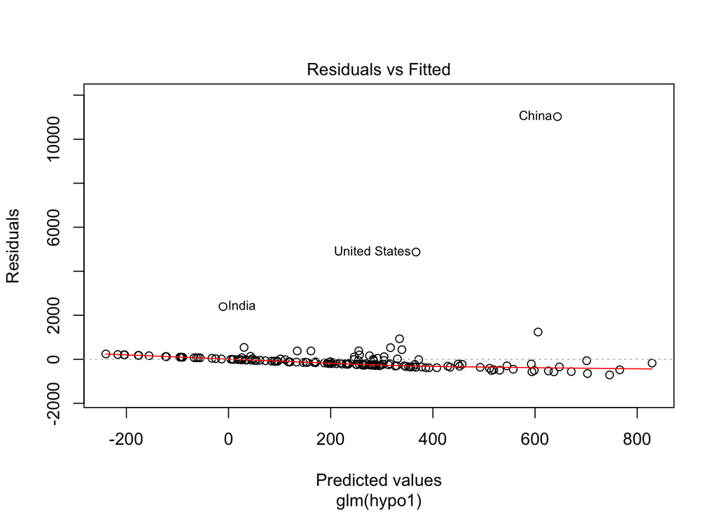

```r
plot(gauss1,1)
```

The linear relationship holds, but it is worth evaluating the outliers.

9.2. Normality of residuals is assumed:

Visual exploration:

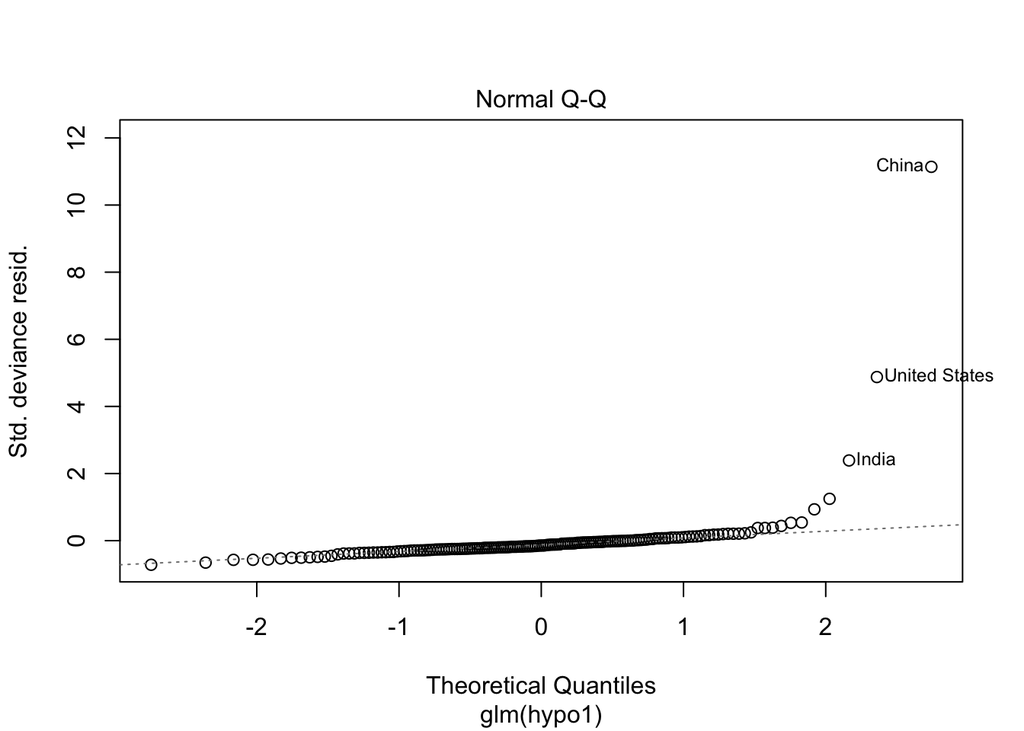

```r
plot(gauss1,2)
```

Mathematical exploration:

```r
shapiro.test(gauss1$residuals)
```

```
##
##  Shapiro-Wilk normality test
##
## data:  gauss1$residuals
## W = 0.27692, p-value < 2.2e-16
```

9.3. Homoscedasticity is assumed, so you need to check if residuals are spread equally along the ranges of predictors:

Visual exploration:

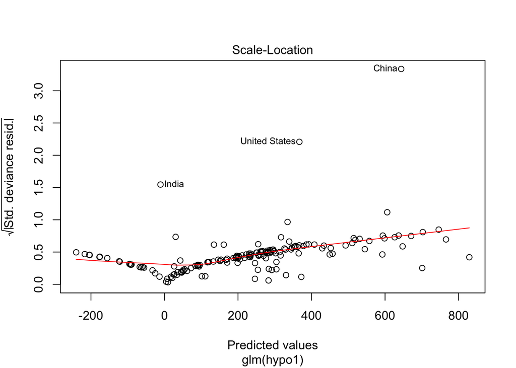

```r
plot(gauss1, 3)
```

Mathematical exploration:

```r
library(lmtest)
bptest(gauss1)
```

```
##
##  studentized Breusch-Pagan test
##
## data:  gauss1
## BP = 5.0921, df = 2, p-value = 0.07839
```

9.4. We assume that there is no colinearity, that is, that the predictors are not correlated.

```r
library(car)
vif(gauss1) # lower than 5 is desirable
```

```
##               demo_FA Humandevelopmentindex
##              1.660031              1.660031
```

9.5. Analize the effect of atypical values. Determine if outliers (points that are far from the rest, but still in the trend) or high-leverage points (far from the trend but close to the rest) are influential:

Visual exploration:

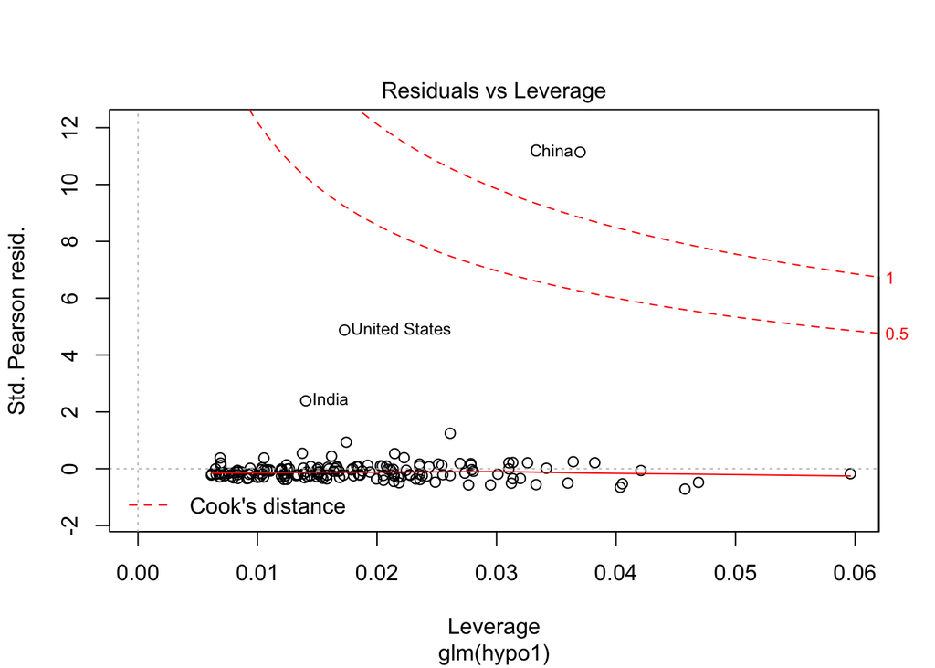

```r
plot(gauss1,5)
```

Querying:

```r
gaussInf=as.data.frame(influence.measures(gauss1)$is.inf)
gaussInf[gaussInf$cook.d,]
```

```
##       dfb.1_ dfb.d_FA dfb.Hmnd dffit cov.r cook.d   hat
## China  FALSE     TRUE     TRUE  TRUE  TRUE   TRUE FALSE
```

10. Finally, a nice summary plot of your work:

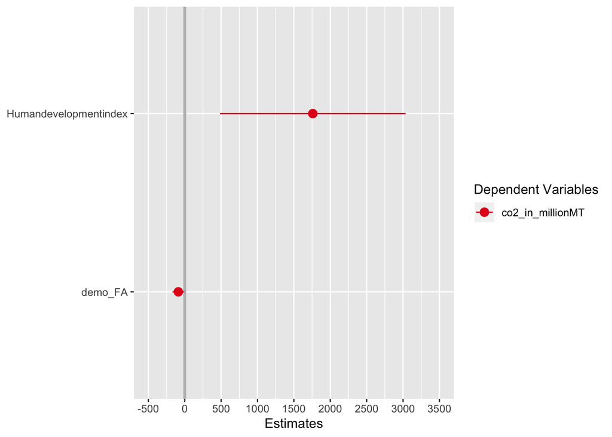

```r
library(sjPlot)
plot_models(gauss1,vline.color = "grey")
```

- **PREDICTIVE APPROACH**
1. Split the data set:

```r
library(caret)
set.seed(123)

selection = createDataPartition(DataRegGauss$co2_in_millionMT,
                                p = 0.75,
                                list = FALSE)
#
trainGauss = DataRegGauss[ selection, ]
#
testGauss  = DataRegGauss[-selection, ]
```

2. Regress with train data

Let’s use cross validation, applying the regression to five samples from the training data set:

```r
ctrl = trainControl(method = 'cv',number = 5)

gauss1CV = train(hypo1,
                 data = trainGauss,
                 method = 'glm',
                 trControl = ctrl)

summary(gauss1CV)
```

```
##
## Call:
## NULL
##
## Deviance Residuals:
##     Min       1Q   Median       3Q      Max
##  -813.7   -296.9   -148.7     -8.3  10931.7
##
## Coefficients:
##                       Estimate Std. Error t value Pr(>|t|)
## (Intercept)            -574.32     482.72  -1.190   0.2365
## demo_FA                 -99.86      53.90  -1.853   0.0664 .
## Humandevelopmentindex  1963.65     838.33   2.342   0.0208 *
## ---
## Signif. codes:  0 '***' 0.001 '**' 0.01 '*' 0.05 '.' 0.1 ' ' 1
##
## (Dispersion parameter for gaussian family taken to be 1317165)
##
##     Null deviance: 166960927  on 123  degrees of freedom
## Residual deviance: 159376961  on 121  degrees of freedom
## AIC: 2104.1
##
## Number of Fisher Scoring iterations: 2
```

3. Evaluate performance

```r
predictedVal<-predict(gauss1CV,testGauss)

postResample(obs = testGauss$co2_in_millionMT, pred=predictedVal)
```

```
##        RMSE    Rsquared         MAE
## 347.3671804   0.1842402 275.4345510
```

## Binary outcome

### * **EXPLANATORY APPROACH**

1. State hypothesis:

```r
hypoDico1=formula(HDIdico~ demo_FA + co2_in_millionMT)
hypoDico2=formula(HDIdico~ demo_FA + co2_in_millionMT + Continent)
```

2. Rescale or reformat

```r
Threshold=median(fromPy$Humandevelopmentindex)
fromPy$HDIdico=fromPy$Humandevelopmentindex>Threshold

fromPy$HDIdico=factor(fromPy$HDIdico,
                      levels = c(F,T),
                      labels = c(0,1))
```

3. Save columns selected

```r
colsNeededDico=c('HDIdico','demo_FA','co2_in_millionMT','Continent')
```

4. Verify data types

```r
str(fromPy[,colsNeededDico])
```

```
## 'data.frame':    164 obs. of  4 variables:
##  $ HDIdico         : Factor w/ 2 levels "0","1": 2 2 2 2 2 2 2 2 2 2 ...
##  $ demo_FA         : num  9.8 9.07 9.52 9.07 6.88 ...
##  $ co2_in_millionMT: num  39.8 39 36.9 847.6 102.5 ...
##  $ Continent       : Factor w/ 7 levels "Africa","Asia",..: 3 3 3 3 2 6 3 3 2 3 ...
```

5. Create subset:

```r
DataRegLogis=fromPy[,colsNeededDico]
#Rename indexes by country
row.names(DataRegLogis)=fromPy$Country
```

6. Compute regression models:

```r
Logi1=glm(hypoDico1,data = DataRegLogis,family = "binomial")
Logi2=glm(hypoDico2,data = DataRegLogis,family = "binomial")
```

7. See results:
- First Hypothesis:

```r
summary(Logi1)
```

```
##
## Call:
## glm(formula = hypoDico1, family = "binomial", data = DataRegLogis)
##
## Deviance Residuals:
##     Min       1Q   Median       3Q      Max
## -3.2128  -0.7870  -0.1653   0.7828   2.0644
##
## Coefficients:
##                   Estimate Std. Error z value Pr(>|z|)
## (Intercept)      -3.257239   0.563122  -5.784 7.28e-09 ***
## demo_FA           0.535818   0.090479   5.922 3.18e-09 ***
## co2_in_millionMT  0.001964   0.001075   1.827   0.0676 .
## ---
## Signif. codes:  0 '***' 0.001 '**' 0.01 '*' 0.05 '.' 0.1 ' ' 1
##
## (Dispersion parameter for binomial family taken to be 1)
##
##     Null deviance: 227.35  on 163  degrees of freedom
## Residual deviance: 168.12  on 161  degrees of freedom
## AIC: 174.12
##
## Number of Fisher Scoring iterations: 7
```

- Second Hypothesis:

```r
summary(Logi2)
```

```
##
## Call:
## glm(formula = hypoDico2, family = "binomial", data = DataRegLogis)
##
## Deviance Residuals:
##      Min        1Q    Median        3Q       Max
## -2.53026  -0.44523  -0.07126   0.29001   2.52255
##
## Coefficients:
##                          Estimate Std. Error z value Pr(>|z|)
## (Intercept)            -4.968e+00  9.440e-01  -5.263 1.42e-07 ***
## demo_FA                 4.431e-01  1.263e-01   3.508 0.000451 ***
## co2_in_millionMT        5.755e-04  6.767e-04   0.850 0.395049
## ContinentAsia           2.751e+00  7.339e-01   3.749 0.000178 ***
## ContinentEurope         5.299e+00  1.207e+00   4.391 1.13e-05 ***
## ContinentEurope/Asia    2.071e+01  1.730e+03   0.012 0.990453
## ContinentNorth America  2.233e+00  8.623e-01   2.589 0.009625 **
## ContinentOceania        1.383e+00  1.277e+00   1.083 0.278943
## ContinentSouth America  2.146e+00  8.855e-01   2.424 0.015353 *
## ---
## Signif. codes:  0 '***' 0.001 '**' 0.01 '*' 0.05 '.' 0.1 ' ' 1
##
## (Dispersion parameter for binomial family taken to be 1)
##
##     Null deviance: 227.35  on 163  degrees of freedom
## Residual deviance: 111.05  on 155  degrees of freedom
## AIC: 129.05
##
## Number of Fisher Scoring iterations: 16
```

8. Search for better model:

```r
lrtest(Logi1,Logi2)
```

```
## Likelihood ratio test
##
## Model 1: HDIdico ~ demo_FA + co2_in_millionMT
## Model 2: HDIdico ~ demo_FA + co2_in_millionMT + Continent
##   #Df  LogLik Df  Chisq Pr(>Chisq)
## 1   3 -84.062
## 2   9 -55.527  6 57.069  1.769e-10 ***
## ---
## Signif. codes:  0 '***' 0.001 '**' 0.01 '*' 0.05 '.' 0.1 ' ' 1
```

Model for the second hypothesis is chosen. 9. Verify the situation of chosen model

9.1. Linearity assumption (Box-Tidwell test)

```r
DataRegLogis2=DataRegLogis
DataRegLogis2$demoTEST=DataRegLogis$demo_FA*log(DataRegLogis$demo_FA)
DataRegLogis2$co2TEST=DataRegLogis$co2_in_millionMT*log(DataRegLogis$co2_in_millionMT)

hypoDicoTest=formula(HDIdico~ demo_FA + co2_in_millionMT + Continent + demoTEST + co2TEST)

summary(glm(hypoDicoTest,data=DataRegLogis2,family = binomial))
```

```
##
## Call:
## glm(formula = hypoDicoTest, family = binomial, data = DataRegLogis2)
##
## Deviance Residuals:
##      Min        1Q    Median        3Q       Max
## -2.69730  -0.38009  -0.09911   0.31448   2.56440
##
## Coefficients:
##                          Estimate Std. Error z value Pr(>|z|)
## (Intercept)            -2.136e+00  1.890e+00  -1.130 0.258417
## demo_FA                -1.363e+00  1.076e+00  -1.267 0.205271
## co2_in_millionMT        6.313e-03  4.491e-03   1.406 0.159825
## ContinentAsia           2.554e+00  7.735e-01   3.302 0.000959 ***
## ContinentEurope         5.148e+00  1.220e+00   4.220 2.44e-05 ***
## ContinentEurope/Asia    2.051e+01  1.689e+03   0.012 0.990311
## ContinentNorth America  2.253e+00  9.033e-01   2.494 0.012615 *
## ContinentOceania        8.893e-01  1.529e+00   0.582 0.560772
## ContinentSouth America  2.003e+00  9.179e-01   2.182 0.029092 *
## demoTEST                7.078e-01  4.291e-01   1.650 0.099029 .
## co2TEST                -6.436e-04  4.825e-04  -1.334 0.182234
## ---
## Signif. codes:  0 '***' 0.001 '**' 0.01 '*' 0.05 '.' 0.1 ' ' 1
##
## (Dispersion parameter for binomial family taken to be 1)
##
##     Null deviance: 227.35  on 163  degrees of freedom
## Residual deviance: 105.89  on 153  degrees of freedom
## AIC: 127.89
##
## Number of Fisher Scoring iterations: 16
```

9.2. We assume that there is no colinearity, that is, that the predictors are not correlated.

```r
vif(Logi2)
```

```
##                      GVIF Df GVIF^(1/(2*Df))
## demo_FA          1.366924  1        1.169155
## co2_in_millionMT 1.035512  1        1.017601
## Continent        1.389199  6        1.027773
```

9.3 Analize the effect of atypical values. Determine if outliers (points that are far from the rest, but still in the trend) or high-leverage points (far from the trend but close to the rest) are influential:

Visual exploration:

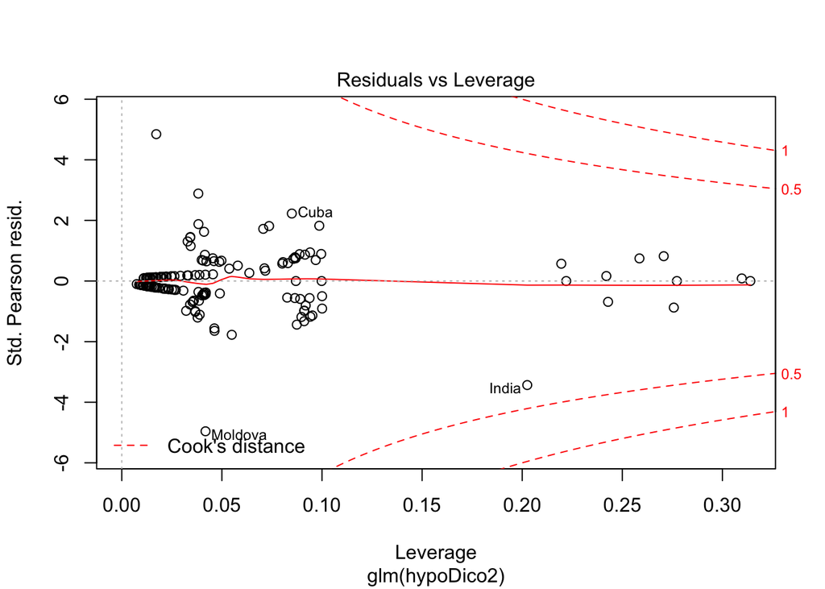

```r
plot(Logi2,5)
```

10. Finally, a nice summary plot of your work by computing the marginal effects:

```r
library(margins)
(modelChosen = margins(Logi2))
```

```
## Average marginal effects
```

```
## glm(formula = hypoDico2, family = "binomial", data = DataRegLogis)
```

```
##  demo_FA co2_in_millionMT ContinentAsia ContinentEurope
##  0.04772        6.197e-05        0.4417          0.7878
##  ContinentEurope/Asia ContinentNorth America ContinentOceania
##                0.8706                  0.343           0.1869
##  ContinentSouth America
##                  0.3265
```

```r
(margins=summary(modelChosen))
```

```
##                  factor    AME     SE       z      p   lower  upper
##        co2_in_millionMT 0.0001 0.0001  0.8560 0.3920 -0.0001 0.0002
##           ContinentAsia 0.4417 0.0925  4.7759 0.0000  0.2605 0.6230
##         ContinentEurope 0.7878 0.1031  7.6447 0.0000  0.5859 0.9898
##    ContinentEurope/Asia 0.8706 0.0627 13.8909 0.0000  0.7478 0.9935
##  ContinentNorth America 0.3430 0.1329  2.5817 0.0098  0.0826 0.6034
##        ContinentOceania 0.1869 0.2006  0.9316 0.3516 -0.2063 0.5801
##  ContinentSouth America 0.3265 0.1388  2.3522 0.0187  0.0545 0.5986
##                 demo_FA 0.0477 0.0110  4.3479 0.0000  0.0262 0.0692
```

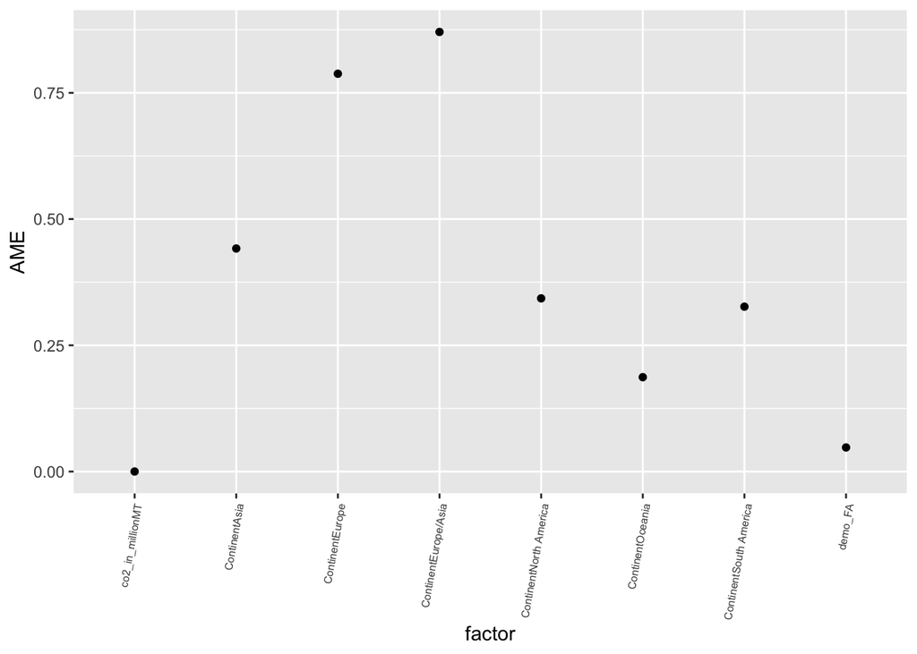

```r
base= ggplot(margins,aes(x=factor, y=AME)) + geom_point()
plot2 = base + theme(axis.text.x = element_text(angle = 80,
                                              size = 6,
                                              hjust = 1))
plot2
```

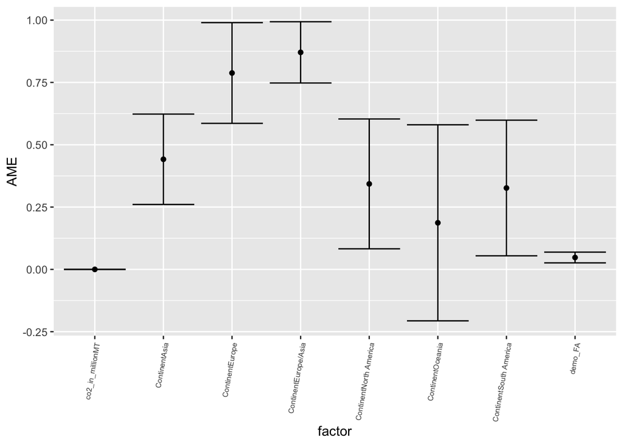

```r
plot2 +  geom_errorbar(aes(ymin=lower, ymax=upper))
```

### * **PREDICTIVE APPROACH**

1. Split the data set:

```r
set.seed(123)

selection = createDataPartition(DataRegLogis$HDIdico,
                                p = 0.75,
                                list = FALSE)
trainLogi = DataRegLogis[selection, ]
testLogi  = DataRegLogis[-selection, ]
```

2. Regress with train data

Let’s use cross validation, applying the regression to five samples from the training data set:

```r
set.seed(123)
ctrl = trainControl(method = 'cv',number = 5)

Logis2CV = train(hypoDico2,
                 data = trainLogi,
                 method = 'glm',
                 family="binomial",
                 trControl = ctrl)
```

3. See results:

```r
summary(Logis2CV)
```

```
##
## Call:
## NULL
##
## Deviance Residuals:
##      Min        1Q    Median        3Q       Max
## -2.29962  -0.50306  -0.08016   0.37691   2.42440
##
## Coefficients:
##                            Estimate Std. Error z value Pr(>|z|)
## (Intercept)              -4.741e+00  1.045e+00  -4.536 5.73e-06 ***
## demo_FA                   4.569e-01  1.480e-01   3.088 0.002018 **
## co2_in_millionMT          3.784e-04  3.530e-04   1.072 0.283683
## ContinentAsia             2.493e+00  7.636e-01   3.265 0.001095 **
## ContinentEurope           4.396e+00  1.234e+00   3.562 0.000368 ***
## `ContinentEurope/Asia`    1.918e+01  1.365e+03   0.014 0.988786
## `ContinentNorth America`  2.279e+00  9.423e-01   2.419 0.015578 *
## ContinentOceania          1.484e+00  1.490e+00   0.996 0.319219
## `ContinentSouth America`  1.420e+00  9.807e-01   1.448 0.147739
## ---
## Signif. codes:  0 '***' 0.001 '**' 0.01 '*' 0.05 '.' 0.1 ' ' 1
##
## (Dispersion parameter for binomial family taken to be 1)
##
##     Null deviance: 171.901  on 123  degrees of freedom
## Residual deviance:  90.786  on 115  degrees of freedom
## AIC: 108.79
##
## Number of Fisher Scoring iterations: 15
```

3. Evaluate performance

3.1 Get predictions on test data

```r
predictions = predict(Logis2CV,
                      newdata=testLogi,
                      type='raw')
```

3.2 Assess performance

```r
confusionMatrix(data=predictions,
                reference=testLogi$HDIdico,
                positive = "1")
```

```
## Confusion Matrix and Statistics
##
##           Reference
## Prediction  0  1
##          0 18  2
##          1  2 18
##
##                Accuracy : 0.9
##                  95% CI : (0.7634, 0.9721)
##     No Information Rate : 0.5
##     P-Value [Acc > NIR] : 9.285e-08
##
##                   Kappa : 0.8
##
##  Mcnemar's Test P-Value : 1
##
##             Sensitivity : 0.90
##             Specificity : 0.90
##          Pos Pred Value : 0.90
##          Neg Pred Value : 0.90
##              Prevalence : 0.50
##          Detection Rate : 0.45
##    Detection Prevalence : 0.50
##       Balanced Accuracy : 0.90
##
##        'Positive' Class : 1
##
```

Here is some help for you to interpret the result:

[interactive chart not shown]